# APS Failure at Scania Trucks

Anastasiia Hryhorzhevska

**1. Proejct Goal**

Minimize maintenance costs of the air pressure system (APS) of Scania truck.

**2. Data**

The training and test sets are given :

- Training set : 60’000 rows $\times$ 171 columns
- Test set : 16’000 $\times$ 171
- Target class : 1st column, “neg” - trucks with failures for components not related to the APS, “pos” - component failures for a specific component of the APS system
- Features : 170 numeric, 70 of which belong to 7 histograms with ten bins each

**3. Methodology**

- Missing values
- Impute missing values with median or another method could be used, e.g. EM
- Sum up all the values that belong to one histogram
- Outlier detection
- Feature significance and feature selection
- Dimensionality Reduction
- Undersampling to deal with imbalaned data
- Split training set into training and validaion sets
- Tune clasiification parameter
- Build model
- Evaluate the result. Falsely predicting a failure has a cost of 10, missing a failure a cost of 500, i.e. $f(X_n, X_p) = 10 \times X_n + 500 \times X_p$

```r
if(!require(dplyr)) {
  install.packages("dplyr"); require(dplyr)}

if(!require(ggplot2)) {
  install.packages("ggplot2"); require(ggplot2)}

if(!require(mice)) {
  install.packages("mice"); require(mice)}

if(!require(tidyr)) {
  install.packages("tidyr"); require(tidyr)}
```

```r
setwd("~/Git/aps-failure@st")
```

Load the data

```r
df      <- read.csv("training_set.csv", sep = ",")
test.df <- read.csv("test_set.csv", sep = ",")
```

```r
summary(df)
```

```
##  class           aa_000            ab_000             ac_000
##  neg:59000   Min.   :      0   na     :46329   0         : 8752
##  pos: 1000   1st Qu.:    834   0      :10977   2130706432: 6188
##              Median :  30776   2      : 1937   na        : 3335
##              Mean   :  59336   4      :  420   2130706434: 1227
##              3rd Qu.:  48668   6      :  148   4         :  768
##              Max.   :2746564   8      :   65   8         :  762
##                                (Other):  124   (Other)   :38968
##      ad_000          ae_000          af_000          ag_000
##  na     :14861   0      :55543   0      :55476   0      :59133
##  0      : 2009   na     : 2500   na     : 2500   na     :  671
##  2      :  937   2      :  601   2      :  576   2      :    9
##  6      :  884   4      :  105   4      :  119   11912  :    5
##  4      :  875   6      :   63   6      :   75   16186  :    5
##  8      :  820   8      :   60   12     :   53   4      :    5
##  (Other):39614   (Other): 1128   (Other): 1201   (Other):  172
##      ag_001          ag_002          ag_003          ag_004
##  0      :58587   0      :56181   0      :46894   0      : 1305
##  na     :  671   na     :  671   na     :  671   na     :  671
##  2      :    9   342    :    9   2      :   22   6      :  294
##  12     :    6   6      :    9   30     :   22   2      :  279
##  15166  :    5   16     :    8   16     :   21   4      :  256
##  530916 :    5   12     :    7   22     :   20   8      :  235
##  (Other):  717   (Other): 3115   (Other):12350   (Other):56960
##      ag_005          ag_006          ag_007          ag_008
##  0      : 1941   0      : 1238   0      :15875   0      :25091
##  na     :  671   na     :  671   na     :  671   na     :  671
##  554    :   17   1002   :   19   10     :   20   4      :   47
##  1628   :   11   1046   :   17   42     :   20   82     :   26
##  1670   :   11   2084   :   17   112    :   19   6      :   22
##  1700   :   11   1028   :   16   4      :   19   30     :   21
##  (Other):57338   (Other):58022   (Other):43376   (Other):34122
##      ag_009          ah_000          ai_000          aj_000
##  0      :40698   na     :  645   0      :53588   0      :46919
##  na     :  671   0      :  133   na     :  629   na     :  629
##  4      :  127   1868   :   14   1200   :    7   58     :  330
##  2      :   81   1974   :   13   3618   :    7   54     :  297
##  6      :   59   2196   :   13   1254   :    6   56     :  280
##  8      :   53   2608   :   13   1444   :    6   52     :  255
##  (Other):18311   (Other):59169   (Other): 5757   (Other):11290
```

[output cut: 289 more lines]

```
##  0      : 4458   0      : 7898   0      :17280   0      :31863
##  na     :  671   na     :  671   na     :  671   na     :  671
##  4      :  313   2      :  420   2      :  299   2      :  301
##  2      :  307   4      :  327   4      :  238   10     :  290
##  8      :  270   6      :  321   10     :  217   8      :  275
##  6      :  261   8      :  273   6      :  197   6      :  258
##  (Other):53720   (Other):50090   (Other):41098   (Other):26342
##      ef_000          eg_000
##  0      :57021   0      :56794
##  na     : 2724   na     : 2723
##  2      :  132   2      :  178
##  4      :   52   4      :   79
##  6      :   13   6      :   55
##  8      :   11   8      :   29
##  (Other):   47   (Other):  142
```

```r
table(df$class)
```

```
##
##   neg   pos
## 59000  1000
```

Split the data into set with neg samples and pos samples

```r
df.neg <- df[df$class == "neg", ]
df.pos <- df[df$class == "pos",]
```

**Missing value treatment**

Compute the percentage of missing values in each feature

```r
df[df == "na"] <- NA
nan.cnt.tbl    <- table(is.na(df[, -1]))
round(nan.cnt.tbl["TRUE"] / sum(nan.cnt.tbl) * 100, 2) # % of NaN value in the entire ds
```

```
## TRUE
## 8.33
```

```r
#' Count % of NaNs by column
#' @x input vector
#' @return % of NaN at 'x'

CntNan <- function(x){
  tbl <- table(is.na(x))
  round(tbl["TRUE"] / sum(tbl) * 100, 2)
}

nans          <- sort(apply(df[, -1], 2, CntNan), decreasing = T)
var.extr.nans <- names(nans[nans > 20]) # take the names of vars that have more than 20% of nans and remove this vars from dataset, other nans will be imputed with mean
var.extr.nans
```

```
##  [1] "br_000" "bq_000" "bp_000" "ab_000" "bo_000" "cr_000" "bn_000" "bm_000"
##  [9] "bl_000" "bk_000" "ad_000" "cf_000" "cg_000" "ch_000" "co_000" "ct_000"
## [17] "cu_000" "cv_000" "cx_000" "cy_000" "cz_000" "da_000" "db_000" "dc_000"
```

Exclude the varibales with more than 20% of NaNs from dataset

```r
df[, 1:ncol(df)] <- sapply(df[, 1:ncol(df)], as.numeric) # convert variables to numeric type
df$class         <- as.factor(df$class)
levels(df$class) <- c("neg", "pos")
df.red           <- select(df, -(var.extr.nans))
dim(df.red)
```

```
## [1] 60000   147
```

Impute the rest of NaNs with median of each variable. The reason why with median is because the data contains many outliers. It is obvious if we look at the basic statustics of teh data, e.g. the function $summary$ returns the Min, 1st Qu., Median, Mean 3rd Qu. and Max values.

```r
# imputes.mice <- mice(df.red, m = 1, maxit = 5, method = "rf") # another method that uses random forest but time costly: we will have 1 imputed datasets, every ds will be created after a maximum of 5 iterations

df.red[, 2:ncol(df.red)] <- sapply(df.red[, 2:ncol(df.red)], function(x) ifelse(is.na(x),
                                                                median(x, na.rm = T),
                                                                x))
```

Now data has no missing values. Let’s move further, and reduce the data by summing up the variables that represent each histogram, e.g. ag_hist = sum(ag_001 + … + ag_009).

```r
colnames(df.red)
```

```
##   [1] "class"  "aa_000" "ac_000" "ae_000" "af_000" "ag_000" "ag_001" "ag_002"
##   [9] "ag_003" "ag_004" "ag_005" "ag_006" "ag_007" "ag_008" "ag_009" "ah_000"
##  [17] "ai_000" "aj_000" "ak_000" "al_000" "am_0"   "an_000" "ao_000" "ap_000"
##  [25] "aq_000" "ar_000" "as_000" "at_000" "au_000" "av_000" "ax_000" "ay_000"
##  [33] "ay_001" "ay_002" "ay_003" "ay_004" "ay_005" "ay_006" "ay_007" "ay_008"
##  [41] "ay_009" "az_000" "az_001" "az_002" "az_003" "az_004" "az_005" "az_006"
##  [49] "az_007" "az_008" "az_009" "ba_000" "ba_001" "ba_002" "ba_003" "ba_004"
##  [57] "ba_005" "ba_006" "ba_007" "ba_008" "ba_009" "bb_000" "bc_000" "bd_000"
##  [65] "be_000" "bf_000" "bg_000" "bh_000" "bi_000" "bj_000" "bs_000" "bt_000"
##  [73] "bu_000" "bv_000" "bx_000" "by_000" "bz_000" "ca_000" "cb_000" "cc_000"
##  [81] "cd_000" "ce_000" "ci_000" "cj_000" "ck_000" "cl_000" "cm_000" "cn_000"
##  [89] "cn_001" "cn_002" "cn_003" "cn_004" "cn_005" "cn_006" "cn_007" "cn_008"
##  [97] "cn_009" "cp_000" "cq_000" "cs_000" "cs_001" "cs_002" "cs_003" "cs_004"
## [105] "cs_005" "cs_006" "cs_007" "cs_008" "cs_009" "dd_000" "de_000" "df_000"
## [113] "dg_000" "dh_000" "di_000" "dj_000" "dk_000" "dl_000" "dm_000" "dn_000"
## [121] "do_000" "dp_000" "dq_000" "dr_000" "ds_000" "dt_000" "du_000" "dv_000"
## [129] "dx_000" "dy_000" "dz_000" "ea_000" "eb_000" "ec_00"  "ed_000" "ee_000"
## [137] "ee_001" "ee_002" "ee_003" "ee_004" "ee_005" "ee_006" "ee_007" "ee_008"
## [145] "ee_009" "ef_000" "eg_000"
```

```r
# ag_hist = sum(ag_000 + ... + ag_009)
# ay_hist = sum(ay_000 + ... + ay_009)) ... , az, ba, cn, cs, ee

df.red <- df.red %>% mutate(ag_hist = ag_000 + ag_001 + ag_002 + ag_003 + ag_004 + ag_005 + ag_006 + ag_007 + ag_008 + ag_009,
                              ay_hist = ay_000 + ay_001 + ay_002 + ay_003 + ay_004 + ay_005 + ay_006 + ay_007 + ay_008 + ay_009,
                              az_hist = az_000 + az_001 + az_002 + az_003 + az_004 + az_005 + az_006 + az_007 + az_008 + az_009,
                              ba_hist = ba_000 + ba_001 + ba_002 + ba_003 + ba_004 + ba_005 + ba_006 + ba_007 + ba_008 + ba_009,
                              cn_hist = cn_000 + cn_001 + cn_002 + cn_003 + cn_004 + cn_005 + cn_006 + cn_007 + cn_008 + cn_009,
                              cs_hist = cs_000 + cs_001 + cs_002 + cs_003 + cs_004 + cs_005 + cs_006 + cs_007 + cs_008 + cs_009,
                              ee_hist = ee_000 + ee_001 + ee_002 + ee_003 + ee_004 + ee_005 + ee_006 + ee_007 + ee_008 + ee_009) %>%
                      select(-c(ag_000 , ag_001 , ag_002 , ag_003 , ag_004 , ag_005 , ag_006 , ag_007 , ag_008 , ag_009,
                                ay_000 , ay_001 , ay_002 , ay_003 , ay_004 , ay_005 , ay_006 , ay_007 , ay_008 , ay_009,
                                az_000 , az_001 , az_002 , az_003 , az_004 , az_005 , az_006 , az_007 , az_008 , az_009,
                                ba_000 , ba_001 , ba_002 , ba_003 , ba_004 , ba_005 , ba_006 , ba_007 , ba_008 , ba_009,
                                cn_000 , cn_001 , cn_002 , cn_003 , cn_004 , cn_005 , cn_006 , cn_007 , cn_008 , cn_009,
                                cs_000 , cs_001 , cs_002 , cs_003 , cs_004 , cs_005 , cs_006 , cs_007 , cs_008 , cs_009,
                                ee_000 , ee_001 , ee_002 , ee_003 , ee_004 , ee_005 , ee_006 , ee_007 , ee_008 , ee_009))
```

**Outliers treatment**

1. PCA to builf clusters and identify the group with exreme value. During implementation memory issue appered, that’s why another method was used.
2. Get rid out of outliers by computing the whiskers, i.e. 1.5 $\times$ IQR above and below 3rd and 1st quartiles, and exclude such observations from further analysis.

upper.whisker = $\min(\max(x), Q_3 + 1.5 * IQR)$ lower.whisker = $\max(\min(x), Q_1 - 1.5 * IQR)$

```r
bxplt         <- boxplot(df.red, plot = F)
upper.whisker <- bxplt$stats[5,]
lower.whisker <- bxplt$stats[1,]

df.outliers <- bxplt$out

FindOutliers <- function (col, up.wh, low.wh){
  val <- col[col < low.wh | col > up.wh]
  idx <- which(col %in% val)
  idx
}

outlier.idx <- vector()

for (c in 2:ncol(df.red))
  outlier.idx <- append(outlier.idx, FindOutliers(df.red[, c], upper.whisker[c], lower.whisker[c]))
outlier.idx <- unique(outlier.idx)

df.red.2 <- df.red[-outlier.idx,]
table(df.red.2$class)
```

```
##
##   neg   pos
## 17434     5
```

In other circumstances I would exclude some outliers, the most extreme, and replace the rest with the median or another metric or do somethng more what comes up during the implementation :), but here, since the task is about evaluating the candidate’s line of thinking and basic code skills, I will split the data into two sets, one of which will have only negative observations and another - only positive. Then replace positive outlier values with the median of posititves and remove negative outliers from db.

```r
df.neg <- df.red[df.red$class == "neg", ]
df.pos <- df.red[df.red$class == "pos",]
```

**Negative observations**

```r
bxplt         <- boxplot(df.neg, plot = F)
upper.whisker <- bxplt$stats[5,]
lower.whisker <- bxplt$stats[1,]

outlier.idx <- vector()

for (c in 2:ncol(df.neg))
  outlier.idx <- append(outlier.idx, FindOutliers(df.neg[, c], upper.whisker[c], lower.whisker[c]))
outlier.idx <- unique(outlier.idx)

df.neg.no.out <- df.neg[-outlier.idx,]
```

**Positive observations**

```r
bxplt         <- boxplot(df.pos, plot = F)
upper.whisker <- bxplt$stats[5,]
lower.whisker <- bxplt$stats[1,]

df.pos.no.out <- df.pos
for (c in 2:ncol(df.pos)){
  outlier.idx <- FindOutliers(df.pos[, c], upper.whisker[c], lower.whisker[c])
  df.pos.no.out[outlier.idx, c] <- median(df.pos.no.out[, c])
}
```

Combine positive and negative ds into one

```r
df.red <- rbind(df.neg.no.out, df.pos.no.out)
dim(df.red)
```

```
## [1] 18075    84
```

```r
summary(df.red)
```

```
##  class           aa_000            ac_000           ae_000      af_000
##  neg:17075   Min.   :      0   Min.   :   1.0   Min.   :1   Min.   :1
##  pos: 1000   1st Qu.:   1944   1st Qu.: 263.0   1st Qu.:1   1st Qu.:1
##              Median :  38406   Median : 674.0   Median :1   Median :1
##              Mean   :  63895   Mean   : 801.2   Mean   :1   Mean   :1
##              3rd Qu.:  45411   3rd Qu.:1306.0   3rd Qu.:1   3rd Qu.:1
##              Max.   :1793716   Max.   :2061.0   Max.   :1   Max.   :1
##      ah_000          ai_000            aj_000           ak_000
##  Min.   :    1   Min.   :   1.00   Min.   :  1.00   Min.   :1
##  1st Qu.: 8568   1st Qu.:   1.00   1st Qu.:  1.00   1st Qu.:1
##  Median :19299   Median :   1.00   Median :  1.00   Median :1
##  Mean   :20041   Mean   :  77.07   Mean   : 11.62   Mean   :1
##  3rd Qu.:30932   3rd Qu.:   1.00   3rd Qu.:  1.00   3rd Qu.:1
##  Max.   :43571   Max.   :4041.00   Max.   :883.00   Max.   :1
##      al_000            am_0             an_000          ao_000
##  Min.   :   1.0   Min.   :    1.0   Min.   :    1   Min.   :    1
##  1st Qu.:   1.0   1st Qu.:    1.0   1st Qu.:13762   1st Qu.:13540
##  Median :   1.0   Median :    1.0   Median :23022   Median :22777
##  Mean   : 429.4   Mean   :  689.8   Mean   :23408   Mean   :23410
##  3rd Qu.:   1.0   3rd Qu.:    1.0   3rd Qu.:33394   3rd Qu.:33660
##  Max.   :9001.0   Max.   :10582.0   Max.   :48193   Max.   :47723
##      ap_000          aq_000          ar_000      as_000      at_000
##  Min.   :    1   Min.   :    1   Min.   :1   Min.   :1   Min.   :   1.00
##  1st Qu.:12292   1st Qu.: 9116   1st Qu.:1   1st Qu.:1   1st Qu.:   1.00
##  Median :22931   Median :16575   Median :1   Median :1   Median :   1.00
##  Mean   :22816   Mean   :16919   Mean   :1   Mean   :1   Mean   :   4.91
##  3rd Qu.:33301   3rd Qu.:24633   3rd Qu.:1   3rd Qu.:1   3rd Qu.:   1.00
##  Max.   :44672   Max.   :34916   Max.   :1   Max.   :1   Max.   :1206.00
##      au_000      av_000         ax_000         bb_000          bc_000
##  Min.   :1   Min.   :   1   Min.   :   1   Min.   :    1   Min.   :   1.0
##  1st Qu.:1   1st Qu.: 297   1st Qu.: 155   1st Qu.:13811   1st Qu.:   1.0
##  Median :1   Median :1369   Median : 818   Median :24113   Median : 488.0
##  Mean   :1   Mean   :1486   Mean   : 854   Mean   :24126   Mean   : 767.5
##  3rd Qu.:1   3rd Qu.:2470   3rd Qu.:1435   3rd Qu.:34416   3rd Qu.:1417.0
##  Max.   :1   Max.   :3856   Max.   :2212   Max.   :49392   Max.   :2807.0
##      bd_000         be_000         bf_000           bg_000          bh_000
##  Min.   :   1   Min.   :   1   Min.   :   1.0   Min.   :    1   Min.   :    1
##  1st Qu.: 911   1st Qu.: 759   1st Qu.:   1.0   1st Qu.: 8574   1st Qu.: 6856
##  Median :1707   Median :1587   Median : 185.0   Median :19299   Median :11547
##  Mean   :1703   Mean   :1750   Mean   : 311.5   Mean   :20040   Mean   :12138
```

[output cut: 71 more lines]

```
##  Max.   :1   Max.   :1   Max.   :27831   Max.   :31140   Max.   :3929
##      ef_000      eg_000     ag_hist          ay_hist          az_hist
##  Min.   :1   Min.   :1   Min.   :  9591   Min.   :    10   Min.   : 17902
##  1st Qu.:1   1st Qu.:1   1st Qu.: 59924   1st Qu.: 40777   1st Qu.: 55832
##  Median :1   Median :1   Median : 73394   Median : 55754   Median : 67983
##  Mean   :1   Mean   :1   Mean   : 72861   Mean   : 55164   Mean   : 67881
##  3rd Qu.:1   3rd Qu.:1   3rd Qu.: 86621   3rd Qu.: 70638   3rd Qu.: 80458
##  Max.   :1   Max.   :1   Max.   :133889   Max.   :114970   Max.   :117972
##     ba_hist          cn_hist          cs_hist          ee_hist
##  Min.   : 60022   Min.   : 24186   Min.   : 36816   Min.   : 42868
##  1st Qu.:115930   1st Qu.: 73802   1st Qu.: 88040   1st Qu.:123143
##  Median :135284   Median : 90055   Median :103777   Median :145700
##  Mean   :134079   Mean   : 89478   Mean   :103953   Mean   :148964
##  3rd Qu.:152320   3rd Qu.:105470   3rd Qu.:120275   3rd Qu.:174510
##  Max.   :221016   Max.   :165222   Max.   :170506   Max.   :253899
```

**Feature selection**

- Remove those variables mean and meadian of which are highly different

```r
df.red <- df.red %>% select(-c(ai_000, aj_000, al_000, am_0, at_000, bc_000, cj_000, cl_000, cm_000, dx_000, dy_000))
summary(df.red)
```

```
##  class           aa_000            ac_000           ae_000      af_000
##  neg:17075   Min.   :      0   Min.   :   1.0   Min.   :1   Min.   :1
##  pos: 1000   1st Qu.:   1944   1st Qu.: 263.0   1st Qu.:1   1st Qu.:1
##              Median :  38406   Median : 674.0   Median :1   Median :1
##              Mean   :  63895   Mean   : 801.2   Mean   :1   Mean   :1
##              3rd Qu.:  45411   3rd Qu.:1306.0   3rd Qu.:1   3rd Qu.:1
##              Max.   :1793716   Max.   :2061.0   Max.   :1   Max.   :1
##      ah_000          ak_000      an_000          ao_000          ap_000
##  Min.   :    1   Min.   :1   Min.   :    1   Min.   :    1   Min.   :    1
##  1st Qu.: 8568   1st Qu.:1   1st Qu.:13762   1st Qu.:13540   1st Qu.:12292
##  Median :19299   Median :1   Median :23022   Median :22777   Median :22931
##  Mean   :20041   Mean   :1   Mean   :23408   Mean   :23410   Mean   :22816
##  3rd Qu.:30932   3rd Qu.:1   3rd Qu.:33394   3rd Qu.:33660   3rd Qu.:33301
##  Max.   :43571   Max.   :1   Max.   :48193   Max.   :47723   Max.   :44672
##      aq_000          ar_000      as_000      au_000      av_000
##  Min.   :    1   Min.   :1   Min.   :1   Min.   :1   Min.   :   1
##  1st Qu.: 9116   1st Qu.:1   1st Qu.:1   1st Qu.:1   1st Qu.: 297
##  Median :16575   Median :1   Median :1   Median :1   Median :1369
##  Mean   :16919   Mean   :1   Mean   :1   Mean   :1   Mean   :1486
##  3rd Qu.:24633   3rd Qu.:1   3rd Qu.:1   3rd Qu.:1   3rd Qu.:2470
##  Max.   :34916   Max.   :1   Max.   :1   Max.   :1   Max.   :3856
##      ax_000         bb_000          bd_000         be_000         bf_000
##  Min.   :   1   Min.   :    1   Min.   :   1   Min.   :   1   Min.   :   1.0
##  1st Qu.: 155   1st Qu.:13811   1st Qu.: 911   1st Qu.: 759   1st Qu.:   1.0
##  Median : 818   Median :24113   Median :1707   Median :1587   Median : 185.0
##  Mean   : 854   Mean   :24126   Mean   :1703   Mean   :1750   Mean   : 311.5
##  3rd Qu.:1435   3rd Qu.:34416   3rd Qu.:2576   3rd Qu.:2747   3rd Qu.: 605.0
##  Max.   :2212   Max.   :49392   Max.   :3561   Max.   :3914   Max.   :1098.0
##      bg_000          bh_000          bi_000          bj_000
##  Min.   :    1   Min.   :    1   Min.   :    1   Min.   :    1
##  1st Qu.: 8574   1st Qu.: 6856   1st Qu.:10854   1st Qu.: 9514
##  Median :19299   Median :11547   Median :20709   Median :19175
##  Mean   :20040   Mean   :12138   Mean   :20771   Mean   :19061
##  3rd Qu.:30928   3rd Qu.:17418   3rd Qu.:30690   3rd Qu.:28870
##  Max.   :43568   Max.   :25231   Max.   :42095   Max.   :38359
##      bs_000          bt_000          bu_000          bv_000
##  Min.   :    1   Min.   :    1   Min.   :    1   Min.   :    1
##  1st Qu.: 2885   1st Qu.:14585   1st Qu.:13784   1st Qu.:13784
##  Median : 7128   Median :24982   Median :24087   Median :24087
##  Mean   : 6744   Mean   :24098   Mean   :24100   Mean   :24099
```

[output cut: 57 more lines]

```
##  Max.   :3929   Max.   :1   Max.   :1   Max.   :133889   Max.   :114970
##     az_hist          ba_hist          cn_hist          cs_hist
##  Min.   : 17902   Min.   : 60022   Min.   : 24186   Min.   : 36816
##  1st Qu.: 55832   1st Qu.:115930   1st Qu.: 73802   1st Qu.: 88040
##  Median : 67983   Median :135284   Median : 90055   Median :103777
##  Mean   : 67881   Mean   :134079   Mean   : 89478   Mean   :103953
##  3rd Qu.: 80458   3rd Qu.:152320   3rd Qu.:105470   3rd Qu.:120275
##  Max.   :117972   Max.   :221016   Max.   :165222   Max.   :170506
##     ee_hist
##  Min.   : 42868
##  1st Qu.:123143
##  Median :145700
##  Mean   :148964
##  3rd Qu.:174510
##  Max.   :253899
```

- Remove all variables that contain the same val for each col, i.e. var(x) == 0, since they are not informative to distinguish two classes

```r
sum.each.col <- apply(df.red[, -1], 2, sum)
col.names    <- names(sum.each.col[sum.each.col == nrow(df.red)])
df.red       <- select(df.red, -col.names)
summary(df.red)
```

```
##  class           aa_000            ac_000           ah_000          an_000
##  neg:17075   Min.   :      0   Min.   :   1.0   Min.   :    1   Min.   :    1
##  pos: 1000   1st Qu.:   1944   1st Qu.: 263.0   1st Qu.: 8568   1st Qu.:13762
##              Median :  38406   Median : 674.0   Median :19299   Median :23022
##              Mean   :  63895   Mean   : 801.2   Mean   :20041   Mean   :23408
##              3rd Qu.:  45411   3rd Qu.:1306.0   3rd Qu.:30932   3rd Qu.:33394
##              Max.   :1793716   Max.   :2061.0   Max.   :43571   Max.   :48193
##      ao_000          ap_000          aq_000          av_000         ax_000
##  Min.   :    1   Min.   :    1   Min.   :    1   Min.   :   1   Min.   :   1
##  1st Qu.:13540   1st Qu.:12292   1st Qu.: 9116   1st Qu.: 297   1st Qu.: 155
##  Median :22777   Median :22931   Median :16575   Median :1369   Median : 818
##  Mean   :23410   Mean   :22816   Mean   :16919   Mean   :1486   Mean   : 854
##  3rd Qu.:33660   3rd Qu.:33301   3rd Qu.:24633   3rd Qu.:2470   3rd Qu.:1435
##  Max.   :47723   Max.   :44672   Max.   :34916   Max.   :3856   Max.   :2212
##      bb_000          bd_000         be_000         bf_000           bg_000
##  Min.   :    1   Min.   :   1   Min.   :   1   Min.   :   1.0   Min.   :    1
##  1st Qu.:13811   1st Qu.: 911   1st Qu.: 759   1st Qu.:   1.0   1st Qu.: 8574
##  Median :24113   Median :1707   Median :1587   Median : 185.0   Median :19299
##  Mean   :24126   Mean   :1703   Mean   :1750   Mean   : 311.5   Mean   :20040
##  3rd Qu.:34416   3rd Qu.:2576   3rd Qu.:2747   3rd Qu.: 605.0   3rd Qu.:30928
##  Max.   :49392   Max.   :3561   Max.   :3914   Max.   :1098.0   Max.   :43568
##      bh_000          bi_000          bj_000          bs_000
##  Min.   :    1   Min.   :    1   Min.   :    1   Min.   :    1
##  1st Qu.: 6856   1st Qu.:10854   1st Qu.: 9514   1st Qu.: 2885
##  Median :11547   Median :20709   Median :19175   Median : 7128
##  Mean   :12138   Mean   :20771   Mean   :19061   Mean   : 6744
##  3rd Qu.:17418   3rd Qu.:30690   3rd Qu.:28870   3rd Qu.:10468
##  Max.   :25231   Max.   :42095   Max.   :38359   Max.   :12834
##      bt_000          bu_000          bv_000          bx_000
##  Min.   :    1   Min.   :    1   Min.   :    1   Min.   :    1
##  1st Qu.:14585   1st Qu.:13784   1st Qu.:13784   1st Qu.:14676
##  Median :24982   Median :24087   Median :24087   Median :25480
##  Mean   :24098   Mean   :24100   Mean   :24099   Mean   :25578
##  3rd Qu.:33608   3rd Qu.:34384   3rd Qu.:34382   3rd Qu.:36296
##  Max.   :45480   Max.   :49349   Max.   :49346   Max.   :52835
##      by_000          bz_000          ca_000          cb_000
##  Min.   :    1   Min.   :    1   Min.   :    1   Min.   :    1
##  1st Qu.: 5220   1st Qu.: 1761   1st Qu.: 6616   1st Qu.: 6718
##  Median : 9239   Median : 5796   Median :12207   Median :13158
##  Mean   :10014   Mean   : 6642   Mean   :13066   Mean   :14117
```

[output cut: 29 more lines]

```
##  Max.   :28495   Max.   :30137   Max.   :27831   Max.   :31140   Max.   :3929
##     ag_hist          ay_hist          az_hist          ba_hist
##  Min.   :  9591   Min.   :    10   Min.   : 17902   Min.   : 60022
##  1st Qu.: 59924   1st Qu.: 40777   1st Qu.: 55832   1st Qu.:115930
##  Median : 73394   Median : 55754   Median : 67983   Median :135284
##  Mean   : 72861   Mean   : 55164   Mean   : 67881   Mean   :134079
##  3rd Qu.: 86621   3rd Qu.: 70638   3rd Qu.: 80458   3rd Qu.:152320
##  Max.   :133889   Max.   :114970   Max.   :117972   Max.   :221016
##     cn_hist          cs_hist          ee_hist
##  Min.   : 24186   Min.   : 36816   Min.   : 42868
##  1st Qu.: 73802   1st Qu.: 88040   1st Qu.:123143
##  Median : 90055   Median :103777   Median :145700
##  Mean   : 89478   Mean   :103953   Mean   :148964
##  3rd Qu.:105470   3rd Qu.:120275   3rd Qu.:174510
##  Max.   :165222   Max.   :170506   Max.   :253899
```

**Correlation between variables**

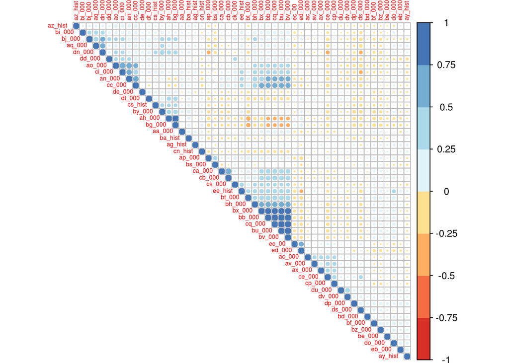

```r
if(!require(corrplot)) {
  install.packages("corrplot"); require(corrplot)}

if(!require(RColorBrewer)) {
  install.packages("RColorBrewer"); require(RColorBrewer)}

cor.mtrx <- cor(df.red[, -1], method = "pearson")

corrplot(cor.mtrx, type="upper", order="hclust", col = brewer.pal(n=8, name="RdYlBu"), tl.cex = 0.5)
```

It is seen that many of the variables have high correlation. Since we don’t have the infromation about the contents of variables and their technical relationships, it is necessary to extract relevant variables using data analysis.

**Variance within variables. Distribution plots**

Let’s have a look at the distribution of the reduced data. We want to have data that normally distributed. Applying certain methods to data that are not normally distributed can give misleading or incorrect results. However, most methods that assume normality are robust enough for all data except the very abnormal.

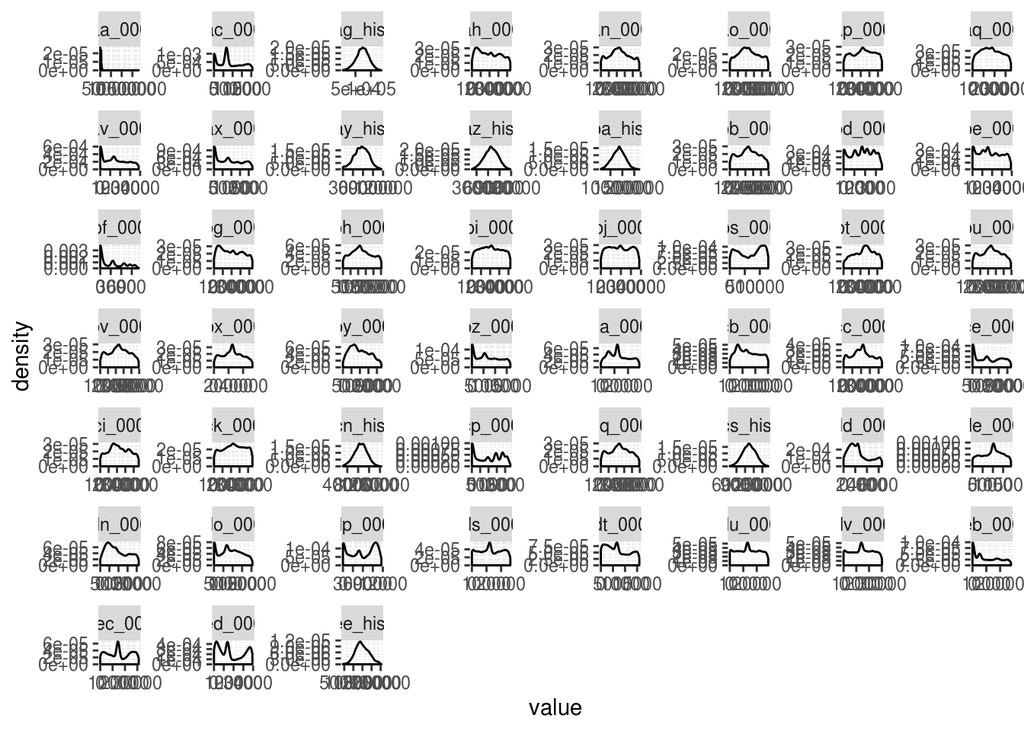

```r
df.red[, -1] %>%
  gather() %>%
    ggplot(aes(value)) +
      facet_wrap(~key, scales = "free")+
      geom_density()
```

O_o, only histogram variables follow normal (Gaussian) distribution. We will crete two datasets fr building classififcation models. The first ds will contain only histogram variabes, the second ds - the most significant variables (the significance of vars will be identfired by either of three methods, PCA, linear regression, random forest).

**Dimenationality reduction. PCA**

The reason to perform PCA:

- to find hidden patterns
- explore correlation between vars
- find significant vars
- prepare data for clustering to exclude outliers

```r
if(!require(FactoMineR)) {
  install.packages("FactoMineR"); require(FactoMineR)}

num.pc  <- 20 # number of principal components to compute
pca.res <- PCA(df.red, quali.sup = 1, scale = T, graph = F, ncp = num.pc)
```

```r
eigenvalues <- pca.res$eig
eigenvalues[1:20,]
```

```
##         eigenvalue percentage of variance cumulative percentage of variance
## comp 1   8.1442617              15.969141                          15.96914
## comp 2   4.9854862               9.775463                          25.74460
## comp 3   2.3753501               4.657549                          30.40215
## comp 4   2.3520301               4.611824                          35.01398
## comp 5   1.9772877               3.877035                          38.89101
## comp 6   1.6318181               3.199643                          42.09065
## comp 7   1.4495415               2.842238                          44.93289
## comp 8   1.3891343               2.723793                          47.65669
## comp 9   1.2798191               2.509449                          50.16614
## comp 10  1.2449512               2.441081                          52.60722
## comp 11  1.0523091               2.063351                          54.67057
## comp 12  1.0213808               2.002707                          56.67327
## comp 13  1.0001084               1.960997                          58.63427
## comp 14  0.9536790               1.869959                          60.50423
## comp 15  0.8986989               1.762155                          62.26639
## comp 16  0.8943003               1.753530                          64.01991
## comp 17  0.8797870               1.725073                          65.74499
## comp 18  0.8713781               1.708585                          67.45357
## comp 19  0.8473774               1.661524                          69.11510
## comp 20  0.8313215               1.630042                          70.74514
```

First twenty PCs explain 70% of variation of entire ds.

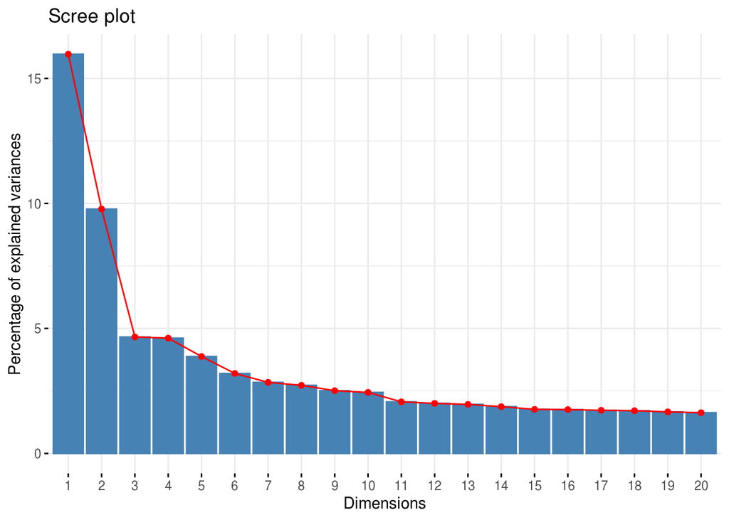

```r
if(!require(factoextra)){
  install.packages("factoextra"); require(factoextra)}

fviz_screeplot(pca.res, ncp = 20, linecolor = "red")
```

Following Kraiser rule, let’s take the first 13 PC (eigenvalues of which are greater than 1) to further analysis.

```r
ncp <- 13
pca.df <- data.frame(pca.res$ind$coord[, 1:ncp])
```

**Variable factor map**

Variable factor map help to find the positively and negatively correlated vars, significance of each var (the closer the var is to circle of correlation, the more important in explaining the variability of ds), and together with individual factor map provide the infromation how the samples relate to each other.

```r
pca.res$var$contrib[, 1:10]
```

```
##                Dim.1        Dim.2        Dim.3        Dim.4        Dim.5
## aa_000  5.336758e-01  0.152156650  0.127102089  0.635431412 1.334821e-01
## ac_000  3.536008e-02  0.036345212  6.259209962 10.143408051 2.868980e-01
## ah_000  8.256036e-01 10.089015224  0.011305118  0.472141438 2.397707e+00
## an_000  5.693793e+00  1.015549558  0.242270346  1.398781373 6.011502e-01
## ao_000  2.832313e+00  3.941479831  0.074827390  1.957825084 1.810006e+00
## ap_000  3.882236e-01  2.202807842  0.493078732  0.900925821 7.372827e+00
## aq_000  7.258458e-01  4.807539892  4.813826042  1.228153466 3.945568e-01
## av_000  3.353450e-07  0.012898830  5.904800582 11.335521370 4.807858e-02
## ax_000  2.908171e-03  0.016050566  6.437988052  9.344654294 2.133301e-01
## bb_000  1.071275e+01  0.251799782  0.003515203  0.006234912 2.012033e+00
## bd_000  2.901518e-03  0.080605195  1.819750500  0.272933797 4.359963e-02
## be_000  5.803361e-02  0.492810587  3.466823057  1.247931683 4.127584e-02
## bf_000  2.353666e-01  2.677674341  2.795748036  2.825377516 2.160854e-01
## bg_000  8.244836e-01 10.086975507  0.011531876  0.472528495 2.401031e+00
## bh_000  5.743055e+00  0.018331507  0.042830729  0.010819018 1.046701e-01
## bi_000  1.179048e+00  2.366634328  1.183318227  0.017169857 4.956382e-01
## bj_000  7.359983e-01  7.152103326  0.257001815  0.002360960 3.011314e-01
## bs_000  1.012437e-03  0.587039905  1.449693800  1.383446539 3.913893e+00
## bt_000  3.088224e+00  2.752419161  0.013212511  0.045593641 2.223450e+00
## bu_000  1.071615e+01  0.251975559  0.003501320  0.006273771 2.016588e+00
## bv_000  1.071609e+01  0.252043866  0.003501680  0.006274931 2.016596e+00
## bx_000  9.301969e+00  0.217800411  0.016364618  0.017374264 8.461168e-01
## by_000  3.147111e-02  7.607305859  1.613146929  0.276794653 1.223385e-01
## bz_000  1.250084e-01  1.893068974  0.927577648  2.375790553 5.617562e-01
## ca_000  2.457011e+00  0.897614643  0.009653684  0.440310320 1.420484e+01
## cb_000  2.619114e+00  0.878852976  0.035856241  0.401903125 1.428222e+01
## cc_000  5.863767e+00  0.476195968  0.547185432  0.695401118 1.668571e-01
## ce_000  9.494904e-01  1.839689946  3.069215531 13.768747917 8.871347e-02
## ci_000  3.295065e+00  3.936369693  0.014674039  1.825800304 2.239232e+00
## ck_000  1.529096e+00  0.002057549  0.247581153  1.034406962 3.105297e+00
## cp_000  5.852616e-02  0.091597036  4.074227003 13.701320639 2.852327e-01
## cq_000  1.071605e+01  0.252211508  0.003501268  0.006279633 2.016295e+00
## dd_000  6.851848e-01  2.666113814  1.007785447  2.476050112 3.703670e-01
## de_000  1.701128e-02  1.454504153  0.033894183  0.035763684 1.347030e-01
## dn_000  4.653101e-01  8.975418310  2.436129150  2.044338819 3.533910e-01
## do_000  5.485588e-01  0.378272974 11.520802453  1.448264477 8.789091e-01
## dp_000  5.966849e-03  2.857863818  5.012958942  0.665382412 9.542797e-01
## ds_000  6.257199e-01  3.360987657  0.498310661  0.942354475 2.890057e+00
## dt_000  3.251056e-01  4.469007466  1.290041174  0.165031667 4.648555e-02
```

[output cut: 49 more lines]

```
## dp_000   1.091569110  0.132567348 5.201576e-01 0.799049543 3.365234e+00
## ds_000   0.185970631  0.556299056 9.038666e-02 1.079142435 2.296051e-02
## dt_000   0.042496394  3.043586503 1.686122e+00 0.214113351 1.463398e-02
## du_000   0.432500694 26.508424427 2.139694e+00 9.389663818 1.572888e-01
## dv_000   0.401137493 26.687107128 2.497358e+00 8.450041102 1.779459e-02
## eb_000   4.464022901  0.002839972 5.611967e-01 4.519457125 2.589595e+00
## ec_00    5.381201268  0.043172342 4.483326e+00 4.952571307 2.539864e+01
## ed_000   3.157435114  0.058020005 6.560730e+00 3.283142332 1.444574e+01
## ag_hist  2.585113634  0.027312990 3.777407e+00 4.084280255 1.865070e+00
## ay_hist  3.518489483  0.312090340 2.254335e-05 2.259225057 8.473761e-02
## az_hist 10.303342578  1.021099456 1.098486e+00 0.032163960 3.370596e+00
## ba_hist  2.124093264  0.499839003 9.734234e+00 8.767512663 2.913684e+00
## cn_hist  0.687149950  0.029027442 4.406250e+00 0.083637131 1.402266e-01
## cs_hist  0.353628178  0.005161646 1.159293e+00 0.001014928 1.236622e+00
## ee_hist  1.123776738  0.006283206 6.662438e-01 1.455341831 1.056527e+00
```

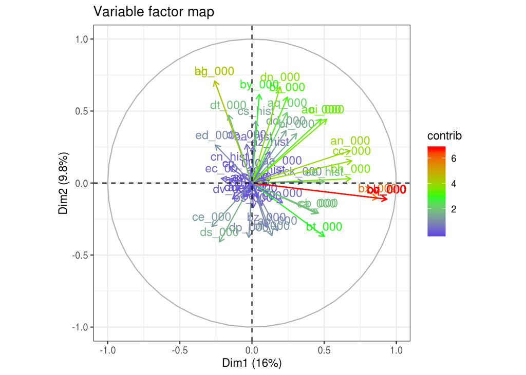

```r
fviz_pca_var(pca.res, col.var="contrib", title = "Variable factor map") +
  scale_color_gradient2(low = "blue", mid = "green", high = "red", midpoint = 3) +
  theme_bw()
```

**Individuals factor map**

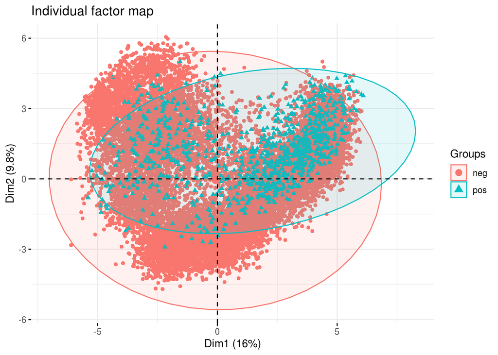

```r
fviz_pca_ind(pca.res, label="none", habillage=df.red$class, addEllipses = T, ellipse.level=0.95, title="Individual factor map")
```

Most of the two principal component axes are overlapped when plotted by class label, but the regions with a large number of positive classes and the regions with a dense and solid negative class are separated.

**Feature significance**

Let’s build few models to identify the most significant vars.

- Linear Regression Model

```r
df.test <- df.red

if(!require(relaimpo)){
  install.packages("relaimpo"); require(relaimpo)}

if(!require(caret)){
  install.packages("caret"); require(caret)}


lm.model      <- lm( class ~. , data = data.frame(cbind(class=df.test$class, scale(df.test[, -1], center = T, scale = T)))) # fit lm() model
lm.importance <- caret::varImp(lm.model)[1]
lm.importance <- data.frame(cbind(Variable = rownames(lm.importance), Importance = lm.importance$Overall))
lm.importance$Importance <- as.numeric(as.character(lm.importance$Importance))
lm.importance <- lm.importance[order(lm.importance$Importance, decreasing = T), ][1:20,]
lm.importance
```

```
##    Variable Importance
## 1    aa_000 183.753503
## 46  ay_hist  10.112125
## 45  ag_hist   9.877836
## 17   bj_000   9.400796
## 29   ci_000   8.397315
## 48  ba_hist   7.283665
## 28   ce_000   6.601885
## 42   eb_000   5.497033
## 49  cn_hist   5.134304
## 25   ca_000   5.002855
## 26   cb_000   4.779099
## 14   bg_000   4.636484
## 34   de_000   4.467215
## 3    ah_000   4.426781
## 51  ee_hist   3.501240
## 22   bx_000   3.318173
## 35   dn_000   2.750011
## 4    an_000   2.600459
## 13   bf_000   2.572454
## 19   bt_000   2.568654
```

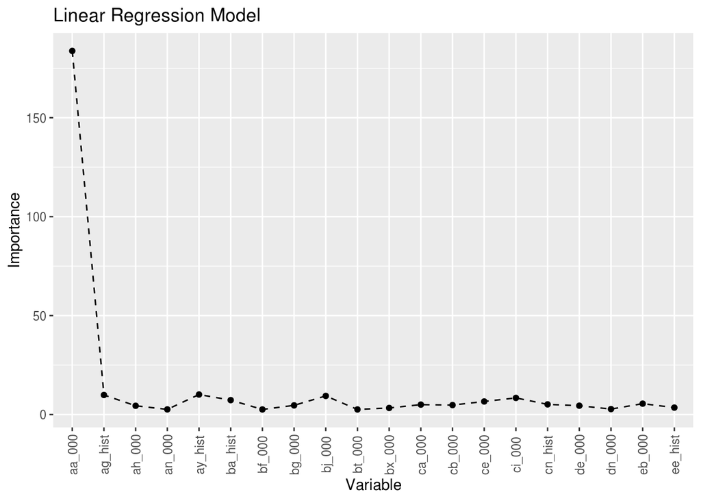

```r
ggplot(data = lm.importance, aes(x =Variable, y = Importance, group=1)) +
  geom_line(linetype = "dashed") +
  geom_point() +
  ggtitle("Linear Regression Model") +
  theme(axis.text.x = element_text(angle = 90, vjust = 0.5, hjust=0.5))
```

- Random Forest

```r
if(!require(caret)){
  install.packages("caret"); require(caret)}

if(!require(randomForest)){
  install.packages("randomForest"); require(randomForest)}

random.forest.mdl <- randomForest(class ~., data = df.red, importance = T)

# Overall importance, i.e. Overall class = pos class + neg class
import <- caret::varImp(random.forest.mdl)[1]
rf.sign.overall <- data.frame(cbind(Variable = rownames(import), Importance = import, Class = "Overall"))
colnames(rf.sign.overall) <- c("Variable", "Importance", "Class")

# Negative class importance
rf.sign.neg <- data.frame(cbind(Variable = rownames(import), Importance = importance(random.forest.mdl, scale = T)[, 1], Class = "neg"))

# Posititve class importance
rf.sign.pos <-data.frame(cbind(Variable = rownames(import), Importance = importance(random.forest.mdl, scale = T)[, 2], Class = "pos"))

rf.sign <- rbind(rf.sign.overall, rf.sign.neg, rf.sign.pos)
rf.sign$Variable <- (rf.sign$Variable)
rf.sign$Importance <- as.numeric(rf.sign$Importance)
```

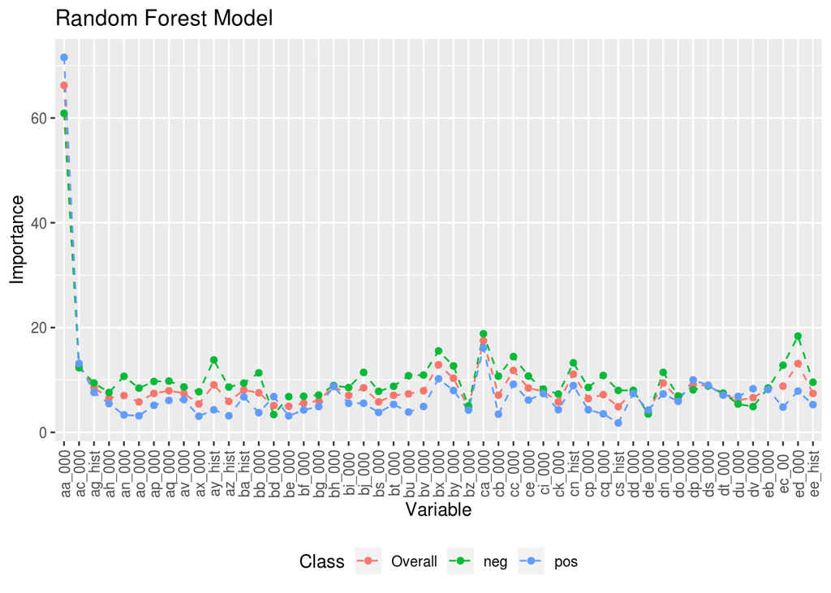

```r
ggplot(data = rf.sign[], aes(x = Variable, y = Importance, group = Class, color = Class)) +
  geom_line(linetype = "dashed") +
  geom_point() +
  ggtitle("Random Forest Model") +
  theme(legend.position = "bottom",  axis.text.x = element_text(angle = 90, vjust = 0.5, hjust=0.5))
```

For further analysis ten most significant var according to RF algorithm was selected:

```r
rf.most.sign <- as.character(rf.sign.overall[order(rf.sign.overall$Importance, decreasing = T), ][1:10, "Variable"])
df.rf.red   <- cbind(class = df.red$class, data.frame(scale(df.red[, rf.most.sign], center = T, scale = T)))
```

**Undersampling and classification**

Since the data are highly imbalanced, complement using the oversampling method or the undersampling method, and balance each class to create a model. Here, I will use only undersampling.

Methodology :

- Randomly sample 1000 observations from negative class and combine them with positive observations. This action will be repeated $m$ times and next steps will be applied for the new sampled subset;
- The new created data set will be divided into training and validation, 75% and 25%;
- The cost, c, parameter in SVM will be tuned;
- Each experiment will repeated n times and average of evaluation metrics were computed;
- Confusion matrices will built and evaluation metrics will computed for both training and validation data sets.

```r
df.mdl <- df.rf.red
```

Some functions for classififcation

- Function for evaluation

```r
#' Evaluation the classification model results
#' @param conf.matr confusion matrix
#' @param data.type if "train", training data, if "test", test data
#' @return df with evaluation measures

EvalClassifier <- function(conf.matr, data.type = "train"){
  measures           <- data.frame(matrix(nrow = 1, ncol = 6))
  colnames(measures) <- c("Cost", "Error", "Accuracy", "Recall", "Precision", "F1")

  measures[1, "Cost"]          <- 10 * conf.matr[2, 1] + 500 * conf.matr[1, 2]
  measures[1, "Accuracy"]      <- (sum(conf.matr[row(conf.matr) == col(conf.matr)]) / sum(conf.matr)) * 100
  measures[1, "Error"]         <- 100 - measures[1, "Accuracy"]
  measures[1, "Recall"]        <- (conf.matr[2, 2] / sum(conf.matr[, 2])) * 100
  measures[1, "Precision"]     <- (conf.matr[2, 2] / sum(conf.matr[2, ])) * 100
  measures[1, "F1"]            <- mean(2 * measures[1, "Precision"] * measures[1, "Recall"] / (measures[1, "Precision"] + measures[1, "Recall"]))

  measures                     <- round(measures, 1)
  measures                     <- cbind(Data = data.type, measures[, -3])

  return(measures)
}
```

**SVM classifier**

Here let’s build only SVM with linear kernel.

- Function for tuning cost, *c*, parameter in SVM classifier

```r
if(!require(kernlab)) {
  install.packages("kernlab"); require(kernlab)}

#' Tuning cost param, c,  parameter in SVM classifier
#' @param input.data training dataset with target variable that should be named as 'class'
#' @return df with cost param, number of support vactors and calculated errors for each *c*

TuneCinSVM <- function (input.data)
{
  cost.params    <- 10^(-2:1)
  errs           <- data.frame(cbind(C = cost.params, Error = vector("numeric", length(cost.params)), nSV = vector("numeric", length(cost.params))))

  for (c in cost.params){
      model <-  ksvm (class ~ ., data = input.data, kernel = 'polydot', C = c, cross = nrow(input.data))
      errs[errs$C == c, "Error"] <- cross(model) * 100
      errs[errs$C == c, "nSV"]   <- nSV(model) * 100
    }

  return(errs)
}
```

- Function for SVM classifier.

```r
if(!require(e1071)) {
  install.packages("e1071"); require(e1071)}


#' @param train.df training data, 'class' is a target var and placed in the first column
#' @param train.df test data, 'class' is a target var and placed in the first column
#' @param best.c best 'c' value obtaied by TuneCinSVM function
#' @return df with evaluation measures for training and test sets, function EvalClassifier is used

SVMClassifier <- function(train.df, test.df, best.c){
  svm.mdl          <- svm (train.df[, -1], train.df$class, type = "C-classification", kernel = 'linear', C = best.c, cross = nrow(train.df))
  prediction.train <- predict(svm.mdl, train.df[, -1])
  conf.matr        <- table(prediction.train, train.df$class)
  eval.tbl.train   <- EvalClassifier(conf.matr, "train")

  prediction.test  <- predict(svm.mdl, test.df[, -1])
  conf.matr        <- table(prediction.test, test.df$class)
  eval.tbl.test    <- EvalClassifier(conf.matr, "test")

  eval.tbl.svm     <- rbind(eval.tbl.train, eval.tbl.test)

  return(list(mdl = svm.mdl, metrics = eval.tbl.svm, conf.matr = conf.matr) )
}
```

```r
set.seed(123)

df.neg <- df.mdl[df.mdl$class == "neg", ]
df.pos <- df.mdl[df.mdl$class == "pos",]

neg.smpl.size  <- 1000
sampling.n.rep <- 1#round(nrow(df.neg) / neg.smpl.size, 0)

eval.tbl.svm.final           <-  data.frame(matrix(0, nrow = 2, ncol = 5))
colnames(eval.tbl.svm.final) <- c("Cost", "Error", "Recall", "Precision", "F1")

for (j in 1:sampling.n.rep){

  neg.ind     <- sample(seq_len(nrow(df.neg)), size = neg.smpl.size) # sample 1000 observations from negative class
  df.neg.smpl <- df.neg[neg.ind,]
  df.smpl     <- rbind(df.pos, df.neg.smpl)

  smp.size <- floor(0.75 * nrow(df.smpl))
  train.ind <- sample(seq_len(nrow(df.smpl)), size = smp.size)

  train.df <- df.smpl[train.ind, ]
  valid.df  <- df.smpl[-train.ind, ] # validation ds

  # rbind(train = table(train.df$class), test = table(valid.df$class))

  svm.c <- TuneCinSVM(train.df) # Tune the 'c' parameter in SVM

  # Plots of obtained cost parameters and number of support vectors SV). The best cost parameter is selected based on the lowest error and smallest number of SV.

  ggplot(data = svm.c, aes(x = C, y = Error, group = 1)) +
    geom_line(linetype = "dashed")+
    geom_point() +
    ggtitle("Error")

  ggplot(data = svm.c, aes(x = C, y = nSV, group = 1)) +
    geom_line(linetype = "dashed", color = "red") +
    geom_point() +
    ggtitle("Number of Support Vectors")

  # Build the model and evaluate the result

  best.c <- svm.c[svm.c$Error == min(svm.c$Error), ] # the lowest error is recieved
  best.c <- best.c[best.c$nSV == min(best.c$nSV), "C"]

  svm.mdl <-  SVMClassifier(train.df, valid.df, best.c)
  eval.tbl.svm <- svm.mdl$metrics[, -1]
  mdl <- svm.mdl$mdl
  conf.matr <- svm.mdl$conf.matr

  n.rep <- 2
  for (i in 1:(n.rep - 1)){
    train.ind  <- sample(seq_len(nrow(df.smpl)), size = smp.size)
    train.df.2 <- df.smpl[train.ind, ]
    valid.df.2 <- df.smpl[-train.ind, ]

    eval.tbl.svm <- eval.tbl.svm + SVMClassifier(train.df.2, valid.df.2, best.c)$metrics[, -1]
  }
  eval.tbl.svm         <- eval.tbl.svm / n.rep
  eval.tbl.svm.final   <- eval.tbl.svm.final + eval.tbl.svm
}
  eval.tbl.svm.final   <- eval.tbl.svm.final / sampling.n.rep
  eval.tbl.svm.final   <- cbind(Data=c("train", "valid"), eval.tbl.svm)
  eval.tbl.svm.final
```

```
##    Data  Cost Error Recall Precision    F1
## 1 train 23000  3.05  93.85       100 96.85
## 2 valid  7000  2.80  94.50       100 97.20
```

**Prediction for test data**

First we must prepare data, i.e. transform to the same view as training set, and deal with missing values and outliers.

```r
summary(test.df)
```

```
##        id        class           aa_000             ab_000
##  Min.   :    1    na:16000   Min.   :       0   na     :12363
##  1st Qu.: 4001               1st Qu.:     928   0      : 2865
##  Median : 8000               Median :   30982   2      :  547
##  Mean   : 8000               Mean   :   67997   4      :  117
##  3rd Qu.:12000               3rd Qu.:   49479   6      :   34
##  Max.   :16000               Max.   :42949672   8      :   26
##                                                 (Other):   48
##         ac_000          ad_000          ae_000          af_000
##  0         : 2289   na     : 3981   0      :14764   0      :14741
##  2130706432: 1673   0      :  519   na     :  690   na     :  690
##  na        :  926   4      :  251   2      :  146   2      :  153
##  2130706434:  321   2      :  249   4      :   27   6      :   28
##  2         :  217   10     :  242   8      :   22   4      :   25
##  4         :  203   16     :  222   10     :   17   8      :   13
##  (Other)   :10371   (Other):10536   (Other):  334   (Other):  350
##      ag_000          ag_001          ag_002          ag_003
##  0      :15749   0      :15575   0      :14954   0      :12442
##  na     :  189   na     :  189   na     :  189   na     :  189
##  8      :    3   102    :    4   66     :    5   22     :    8
##  2      :    2   2      :    4   10     :    3   164    :    6
##  776    :    2   1656   :    3   12     :    3   30     :    6
##  101602 :    1   18     :    3   4      :    3   300    :    6
##  (Other):   54   (Other):  222   (Other):  843   (Other): 3343
##      ag_004          ag_005          ag_006          ag_007          ag_008
##  0      :  340   0      :  499   0      :  326   0      : 4139   0      :6684
##  na     :  189   na     :  189   na     :  189   na     :  189   na     : 189
##  6      :   93   1188   :    5   1952   :    8   390    :    9   4      :  20
##  4      :   80   1232   :    5   1068   :    7   12     :    8   12     :  11
##  8      :   59   1330   :    5   1860   :    7   68     :    8   56     :   8
##  2      :   57   2016   :    5   2554   :    7   16     :    7   14     :   7
##  (Other):15182   (Other):15292   (Other):15456   (Other):11640   (Other):9081
##      ag_009          ah_000          ai_000          aj_000
##  0      :10797   na     :  175   0      :14200   0      :12476
##  na     :  189   0      :   30   na     :  163   na     :  163
##  4      :   41   1870   :    6   942    :    4   56     :   81
##  8      :   19   2904   :    6   1000   :    3   54     :   77
##  6      :   17   1226   :    5   10794  :    3   58     :   73
##  2      :   13   1342   :    5   1344   :    3   60     :   73
##  (Other): 4924   (Other):15773   (Other): 1624   (Other): 3057
```

[output cut: 265 more lines]

```
##  0      :  406   0      :  469   0      :  735   0      : 1151
##  na     :  192   na     :  192   na     :  192   na     :  192
##  10     :  116   16     :   71   22     :   85   4      :   88
##  12     :  116   24     :   65   28     :   82   2      :   87
##  8      :  116   26     :   65   18     :   77   14     :   74
##  14     :   89   30     :   65   20     :   77   22     :   70
##  (Other):14965   (Other):15073   (Other):14752   (Other):14338
##      ee_007          ee_008          ee_009         ef_000          eg_000
##  0      : 2061   0      : 4500   0      :8432   0      :15167   0      :15107
##  na     :  192   na     :  192   na     : 192   na     :  762   na     :  762
##  2      :   95   2      :   73   10     :  90   2      :   36   2      :   49
##  10     :   78   4      :   57   2      :  80   4      :   11   4      :   22
##  4      :   77   6      :   57   4      :  73   6      :    9   6      :   15
##  6      :   72   12     :   51   8      :  71   8      :    5   8      :   11
##  (Other):13425   (Other):11070   (Other):7062   (Other):   10   (Other):   34
```

Prepare test ds

```r
test.df[test.df == "na"] <- NA

test.ids                   <- test.df$id
test.df[, 3:ncol(test.df)] <- sapply(test.df[, 3:ncol(test.df)], as.numeric) # convert variables to numeric type
test.red.df                <- test.df[, -1] # remove column id from ds

# 1. Missing values : impute with median
test.red.df[, 2:ncol(test.red.df)] <- sapply(test.red.df[, 2:ncol(test.red.df)], function(x) ifelse(is.na(x),
                                                                median(x, na.rm = T),
                                                                x))
# 2. Summ up the variables that represent each histogram, e.g. ag_hist = sum(ag_001 + ... + ag_009), and select only those variables which RF model predict asthe most significant

test.red.df <- test.red.df %>% mutate(ag_hist = ag_000 + ag_001 + ag_002 + ag_003 + ag_004 + ag_005 + ag_006 + ag_007 + ag_008 + ag_009,
                              ay_hist = ay_000 + ay_001 + ay_002 + ay_003 + ay_004 + ay_005 + ay_006 + ay_007 + ay_008 + ay_009,
                              az_hist = az_000 + az_001 + az_002 + az_003 + az_004 + az_005 + az_006 + az_007 + az_008 + az_009,
                              ba_hist = ba_000 + ba_001 + ba_002 + ba_003 + ba_004 + ba_005 + ba_006 + ba_007 + ba_008 + ba_009,
                              cn_hist = cn_000 + cn_001 + cn_002 + cn_003 + cn_004 + cn_005 + cn_006 + cn_007 + cn_008 + cn_009,
                              cs_hist = cs_000 + cs_001 + cs_002 + cs_003 + cs_004 + cs_005 + cs_006 + cs_007 + cs_008 + cs_009,
                              ee_hist = ee_000 + ee_001 + ee_002 + ee_003 + ee_004 + ee_005 + ee_006 + ee_007 + ee_008 + ee_009)

test.red.df <- test.red.df[, rf.most.sign]

# 3. Outliers treating. Replace all outliers with median value of each column

bxplt         <- boxplot(test.red.df, plot = F)
upper.whisker <- bxplt$stats[5,]
lower.whisker <- bxplt$stats[1,]

for (c in 1:ncol(test.red.df)){
  outlier.idx <- FindOutliers(test.red.df[, c], upper.whisker[c], lower.whisker[c])
  test.red.df[outlier.idx, c] <- median(test.red.df[, c])
}

#4. Normalize data

test.red.df.norm <- data.frame(scale(test.red.df, center = T, scale = T))
```

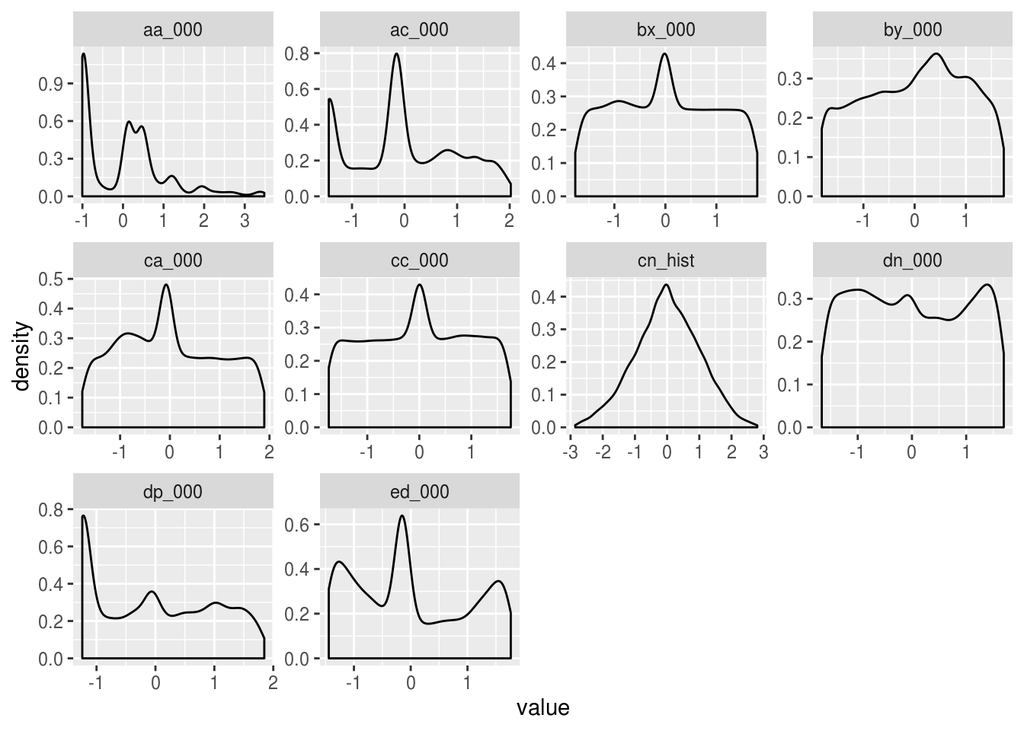

```r
test.red.df.norm %>%
  gather() %>%
    ggplot(aes(value)) +
      facet_wrap(~key, scales = "free")+
      geom_density()
```

```r
prediction.test <- predict(mdl, test.red.df.norm)
write.table(data.frame(prediction.test), "~/Git/aps-failure@st/aps_prediction.csv", append = FALSE, sep = ",", row.names = T, col.names = F)
```

```bash
ls -lh ~/Git/aps-failure@st
```

```
## total 55M
## drwxr-xr-x 3 anastasiia anastasiia 4,0K Aug 22 14:22 aps-notebook_files
## -rw-r--r-- 1 anastasiia anastasiia 616K Aug 20 13:06 aps-notebook.html
## -rw-r--r-- 1 anastasiia anastasiia  25K Aug 22 14:35 aps-notebook.Rmd
## -rw-r--r-- 1 anastasiia anastasiia 208K Aug 22 14:47 aps_prediction.csv
## -rwxr-xr-x 1 anastasiia anastasiia 5,0K May 11  2016 IDA2016Challenge.txt
## -rw-r--r-- 1 anastasiia anastasiia   16 Aug 20 11:07 README.md
## -rwxr-xr-x 1 anastasiia anastasiia  12M May 11  2016 test_set.csv
## -rwxr-xr-x 1 anastasiia anastasiia  43M May 11  2016 training_set.csv
```